# Project №5. Log regression

# 1 Brief exploratory data analysis

A brief exploratory analysis of the data was carried out in order to identify some missing values in our data, find errors in values.

| admit | gre | gpa | rank |
| --- | --- | --- | --- |
| 0 | 380 | 3.61 | 3 |
| 1 | 660 | 3.67 | 3 |
| 1 | 800 | 4.00 | 1 |
| 1 | 640 | 3.19 | 4 |
| 0 | 520 | 2.93 | 4 |
| 1 | 760 | 3.00 | 2 |

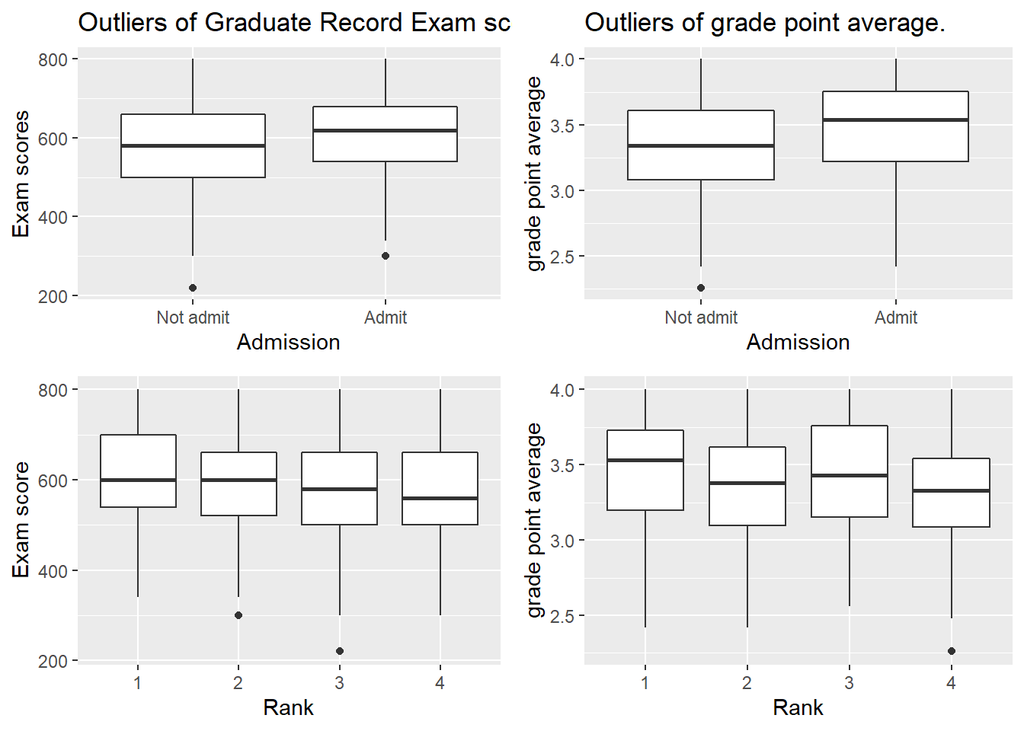

As we’re going to build a log regression model, it’s better to get rid of outliers. We removed observations N: 290, 305, 72

There are 397 observations in our dataframe now and 397 of them are full (without NA).

Also make all binary variables factorial. So dataframe structure is following:

```
## 'data.frame':    397 obs. of  4 variables:
##  $ admit: Factor w/ 2 levels "0","1": 1 2 2 2 1 2 2 1 2 1 ...
##  $ gre  : int  380 660 800 640 520 760 560 400 540 700 ...
##  $ gpa  : num  3.61 3.67 4 3.19 2.93 3 2.98 3.08 3.39 3.92 ...
##  $ rank : Factor w/ 4 levels "1","2","3","4": 3 3 1 4 4 2 1 2 3 2 ...
```

After that we visualized the possibility of admission depending on other variables:

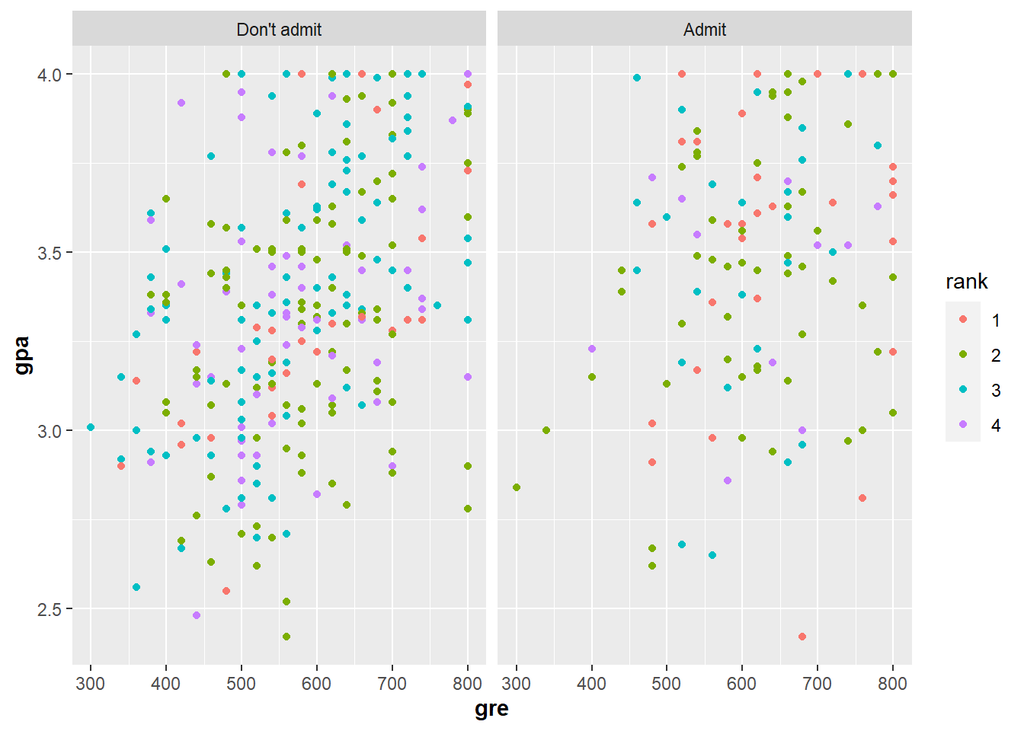

# 2 Building the model

We can now build a model

```
## Analysis of Deviance Table (Type II tests)
##
## Response: admit
##      LR Chisq Df Pr(>Chisq)
## gre    4.1071  1    0.04270 *
## gpa    5.8508  1    0.01557 *
## rank  21.5437  3  8.116e-05 ***
## ---
## Signif. codes:  0 '***' 0.001 '**' 0.01 '*' 0.05 '.' 0.1 ' ' 1
```

As we can see, all predictors in our model are significant.

So *final model* is the following:

# 3 Model diagnostics

After that, we diagnosed the limits of applicability of our model

## 3.1 Linearity

It is quite fine.

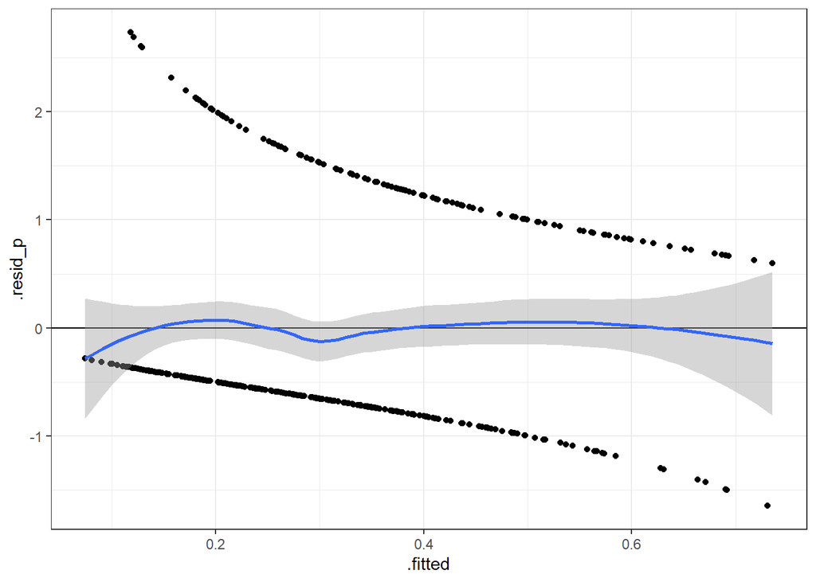

## 3.2 Superdispersion

We checked the data for superdispersion using the author’s function. Everything is fine

```
##       chisq       ratio         rdf           p
## 395.7389215   1.0121200 391.0000000   0.4236351
```

## 3.3 Multicollinearity

Also we’ve checked multicollinearity and we see a weak correlation between the variables fre and gpa. However everything is fine.

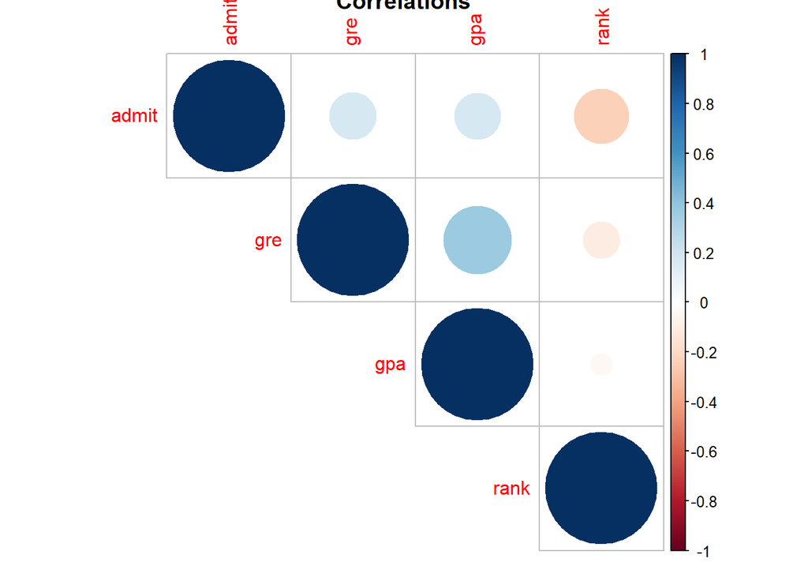

# 4 Model predictions

We checked the possibility of building such a model, now we can try to make predictions based on it.

We calculated the probability of admission based on the independent variables and append new variable “predicted” to our dataframe which means probability of admission based on our model.

```
##         admit gre  gpa rank predicted
## 1 Don't admit 380 3.61    3 0.1747340
## 2       Admit 660 3.67    3 0.2919664
## 3       Admit 800 4.00    1 0.7353768
## 4       Admit 640 3.19    4 0.1804161
## 5 Don't admit 520 2.93    4 0.1207512
## 6       Admit 760 3.00    2 0.3689251
```

We visualised ROC-curve to evaluate our model

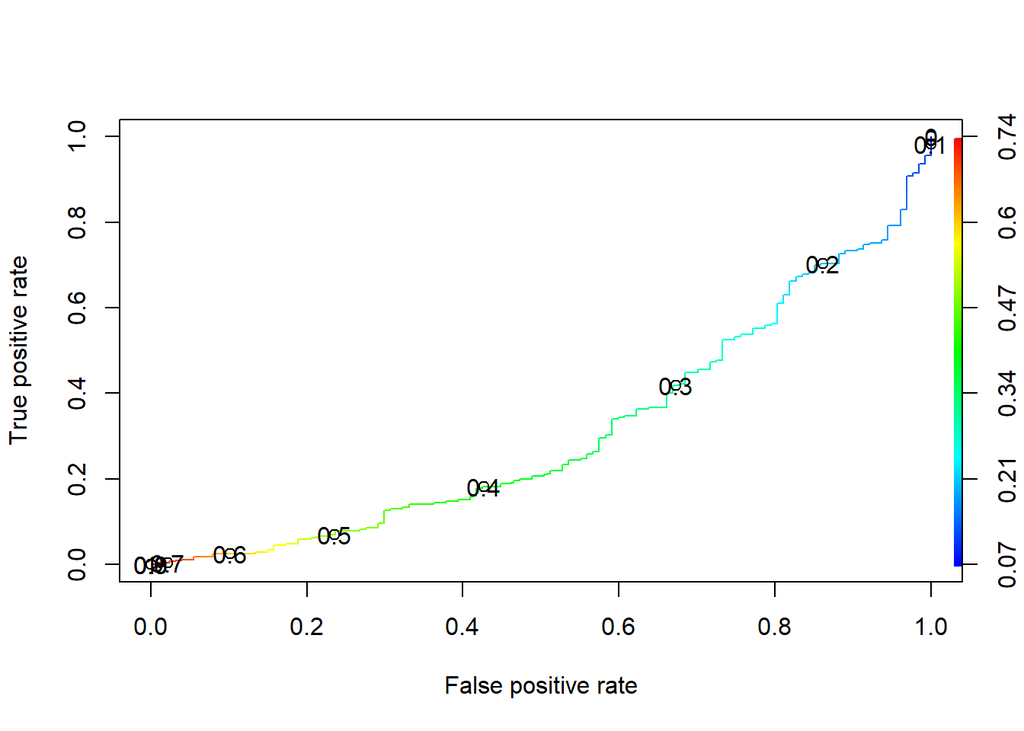

After that, we calculated and visualized the limit separating admission from non-admission. As it showm on the plot it turned out to be equal to 0.32.

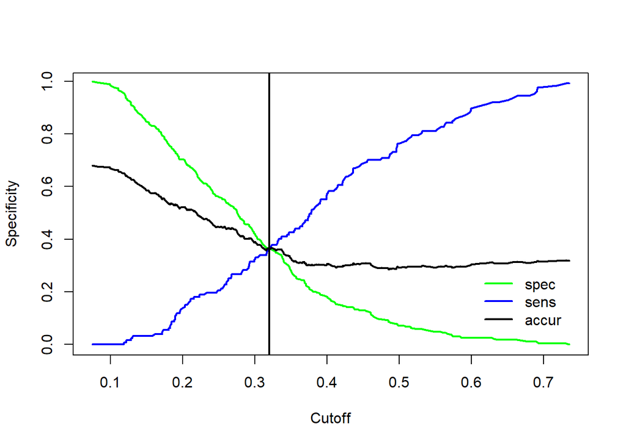

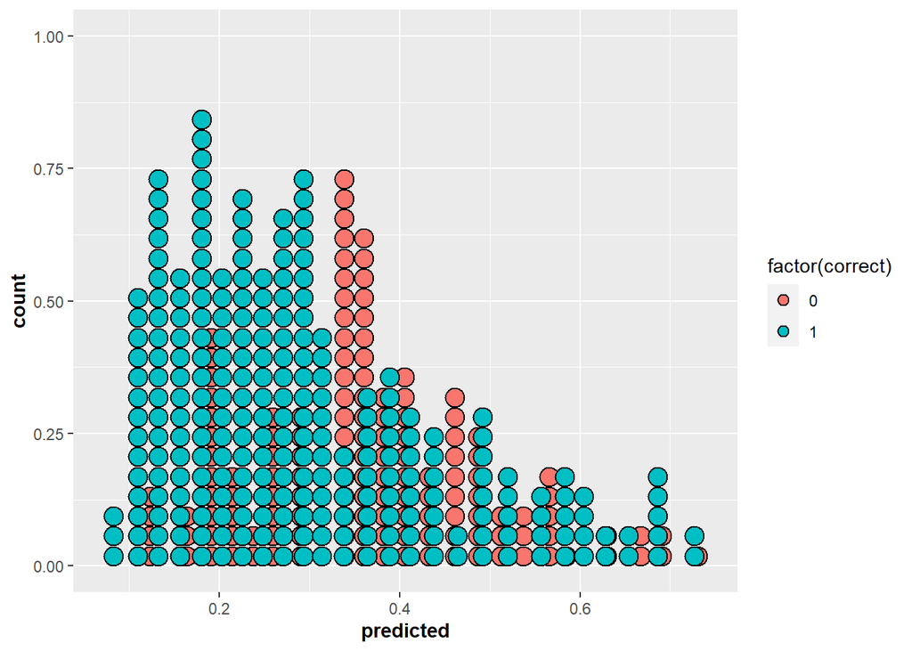

## 4.1 Using model on test dataset

| rank | gre | gpa |
| --- | --- | --- |
| 1 | 340.0000 | 3.453115 |
| 1 | 359.1667 | 3.453115 |
| 1 | 378.3333 | 3.453115 |
| 1 | 397.5000 | 3.453115 |
| 1 | 416.6667 | 3.453115 |
| 1 | 435.8333 | 3.453115 |

## 4.2 Visualising predictions

### 4.2.1 Predictions at the scale of the link function

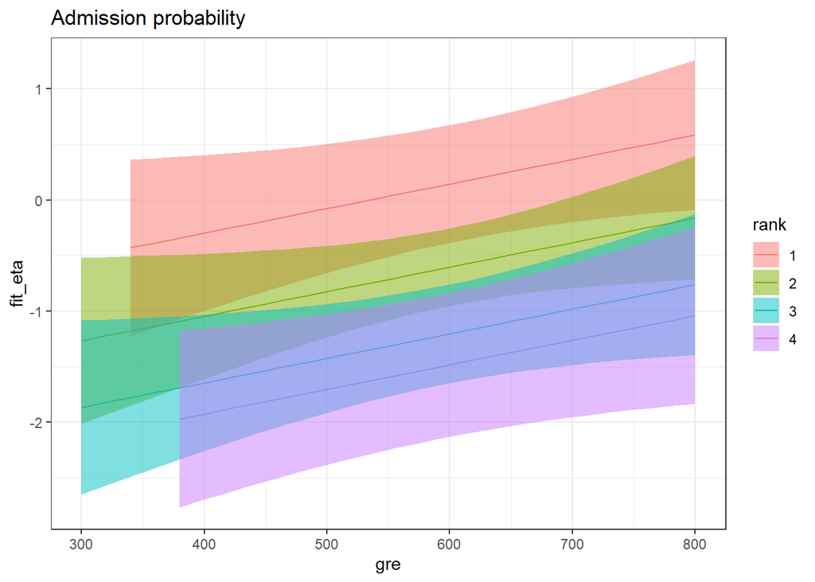

### 4.2.2 Plot of Predictions at Response Scale

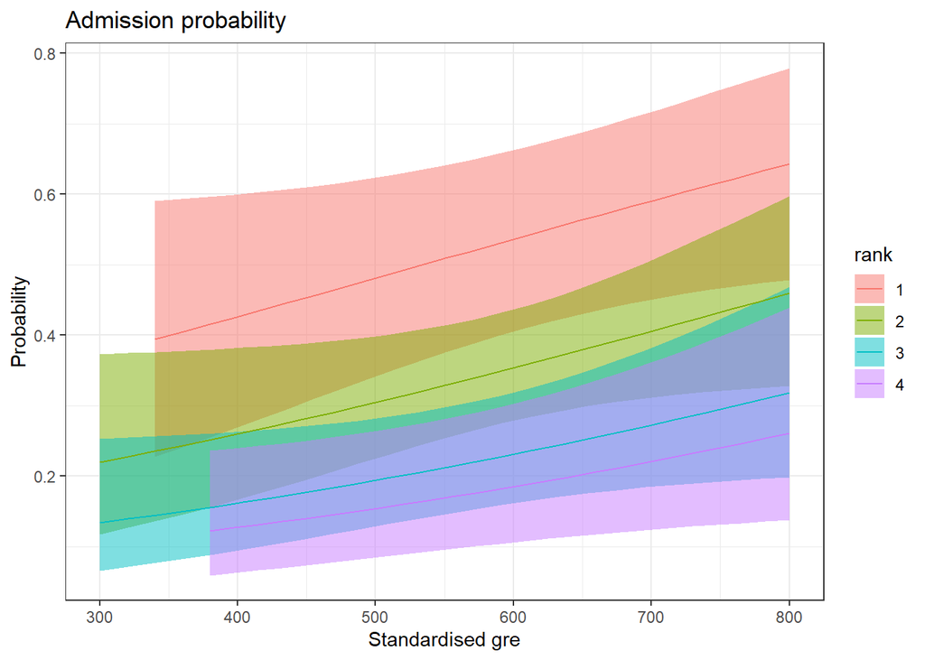

### 4.2.3 Test dataset observation classification

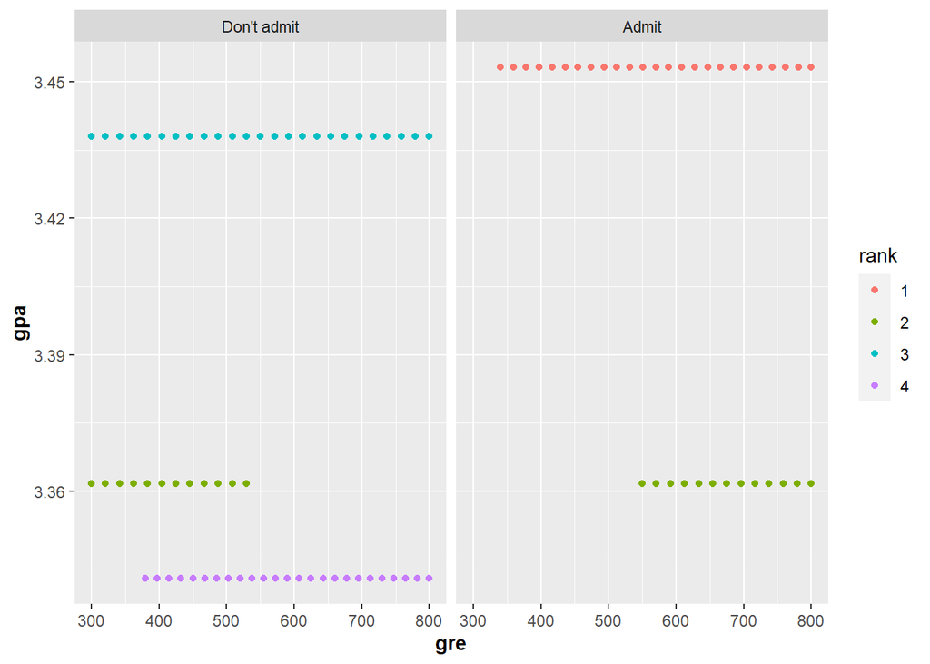

As we can see all graduation exam scores and school rank significantly determine admission.